# Exercises 6 - solutions

Maria Cuellar

2025-10-21

Note: use city_crime_spending.csv.

```r
library(tidyverse)
dat <- read_csv("/Users/mariacuellar/Github/crim_data_analysis/data/city_crime_spending.csv")
```

**1. Question** For two quantitative variables (x and y): Write down the requirements for each of these steps.

- Do visual EDA: Draw a scatterplot and describe the association, form, strengh, and outliers.
- Do quantitative EDA: Check whether the two variables are quantitative, whether their relationship is straight enough, and whether there are any outliers.
- Fit a linear model: Check assumptions of linear regression.
- Test assumptions of linear regression: Linear relationship between x and y, Independence between observations, Homoscedasticity of errors, and Normality of y for a given x. Also, check that there are no influential outliers.
- Interpret coefficient of x to do inference: Only if the assumptions of linear regression are satisfied.

**Instructions** Fit a simple linear regression for police_spending regressed onto population.

**2. Question** What is the null hypothesis for doing inference? What is the research question you could ask here?

The null hypothesis is that there is no relationship between population and police_spending.

**3. Question** What is the coefficient of determination? (The one called Multiple R-squared. The other one has a penalty for adding more covariates, so we won’t need it here.) What does this mean?

I fit a linear model:

```r
out <- lm(police_spending ~ population, data=dat)
```

And look at the R squared.

```r
summary(out)
```

```
##
## Call:
## lm(formula = police_spending ~ population, data = dat)
##
## Residuals:
##      Min       1Q   Median       3Q      Max
## -148.345  -25.665   -2.046   20.840  168.405
##
## Coefficients:
##              Estimate Std. Error t value Pr(>|t|)
## (Intercept) 9.078e+01  3.800e+00   23.89   <2e-16 ***
## population  3.186e-04  6.558e-06   48.59   <2e-16 ***
## ---
## Signif. codes:  0 '***' 0.001 '**' 0.01 '*' 0.05 '.' 0.1 ' ' 1
##
## Residual standard error: 42.17 on 498 degrees of freedom
## Multiple R-squared:  0.8258, Adjusted R-squared:  0.8254
## F-statistic:  2360 on 1 and 498 DF,  p-value: < 2.2e-16
```

The (Multiple) R-squared is 0.8258. This means that there is a strong association between population and police_spending.

**4. Question** Test the assumptions of the linear regression.

First, draw a scatterplot.

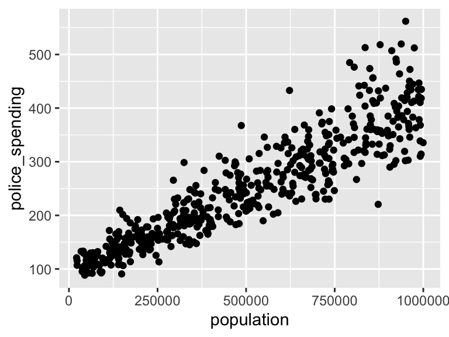

```r
dat %>% ggplot(aes(x=population, y=police_spending)) + geom_point()
```

For quantitative EDA, I check the conditions for correlation: x and y are quantitative variables, the relationship between x and y is straight enough, and there are no noticeable outliers. Therefore, I go ahead and calculate the correlation.

```r
dat %>% summarize(correlation = cor(population, police_spending))
```

```
## # A tibble: 1 × 1
##   correlation
##         <dbl>
## 1       0.909
```

I draw the diagnostic plots:

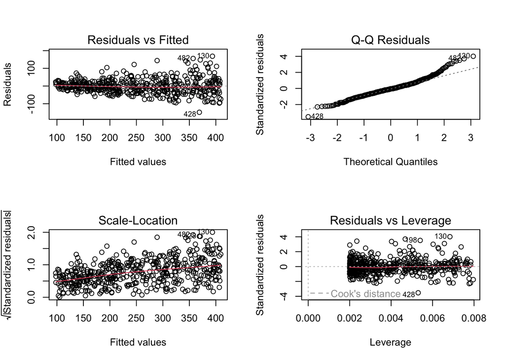

```r
par(mfrow=c(2,2))
plot(out)
```

```r
par(mfrow=c(1,1))
```

And then test assumptions:

1. Linear relationship between x and y: There is a linear relationship between x and y, shown in the scatterplot.
2. Independence between observations: I cannot test for independence between observations, but I don’t see any evidence of clumping to suggest strong dependencies.
3. Homoscedasticity of errors: There is a clear difference in variance of the errors shown in the scale-location plot, as well as in the residuals vs. fitted plot and the scatterplot. This assumption is NOT met.
4. Normality of y for a given x: The q-q plot shows the points mostly on the diagonal, except for the ends. This shows me the assumption is mostly (sufficiently) met.
5. There are no influential outliers.
- For visual EDA: I draw a scatterplot. The scatterplot shows that the two variables have a positive association, a linear form, the relationship is strong (although I do notice changing variance throughout “population”), and there are no clear outliers.

**5. Question** Should you interpret the coefficients? If so, go ahead and interpret the coefficients. If not, then give a satatement for why you should not interpret them.

Since the assumptions of linear regression are NOT fully met, I will not interpret the coefficients.